# Tercera Sesión

Temas vistos:

- Manejo de valores faltantes
- Análisis exploratorio de datos
- KnitR
- Market Basket Analysis usando la librería arules

## Manejo de valores faltantes

Muchas veces nos toca trabajar con sets de datos en donde algunas filas no tienen valores. Esto complica las cosas ya que al intentar realizar operaciones en donde hay datos faltantes, obtendremos errores.

Si la cantidad de datos faltantes no son más de un 10%, podemos omitir estos datos de nuestro dataframe.

```r
## Busar si nuestro set de datos tienen valores faltantes

data <- airquality
sum(is.na(data))
```

```
## [1] 44
```

```r
## Utilizamos la funcion na.omit() para omitir los datos faltantes en nuestro dataframe

str(na.omit(data))
```

```
## 'data.frame':    111 obs. of  6 variables:
##  $ Ozone  : int  41 36 12 18 23 19 8 16 11 14 ...
##  $ Solar.R: int  190 118 149 313 299 99 19 256 290 274 ...
##  $ Wind   : num  7.4 8 12.6 11.5 8.6 13.8 20.1 9.7 9.2 10.9 ...
##  $ Temp   : int  67 72 74 62 65 59 61 69 66 68 ...
##  $ Month  : int  5 5 5 5 5 5 5 5 5 5 ...
##  $ Day    : int  1 2 3 4 7 8 9 12 13 14 ...
##  - attr(*, "na.action")= 'omit' Named int  5 6 10 11 25 26 27 32 33 34 ...
##   ..- attr(*, "names")= chr  "5" "6" "10" "11" ...
```

```r
summary(data$Ozone)
```

```
##    Min. 1st Qu.  Median    Mean 3rd Qu.    Max.    NA's
##    1.00   18.00   31.50   42.13   63.25  168.00      37
```

```r
oz_mean <- mean(data$Ozone, na.rm = TRUE)

data$Ozone[which(is.na(data$Ozone))] <- oz_mean

summary(data$Ozone)
```

```
##    Min. 1st Qu.  Median    Mean 3rd Qu.    Max.
##    1.00   21.00   42.13   42.13   46.00  168.00
```

## Análisis exploratorio de datos

El análisis exploratorio de datos es la parte más importante en lo que llamamos ‘ingeniería de variables’. Esta es la parte en donde obtenemos los insights de la información y definimos cuáles son las variables que afectan nuestro resultado y de qué manera nos afectan.

Para realizar un análisis exploratorio de datos, es necesario primero conocer el set de datos con el que estamos trabajando.

```r
data <- read.csv("all_stocks_2017-01-01_to_2018-01-01.csv")

str(data)
```

```
## 'data.frame':    7781 obs. of  7 variables:
##  $ Date  : Factor w/ 251 levels "2017-01-03","2017-01-04",..: 1 2 3 4 5 6 7 8 9 10 ...
##  $ Open  : num  179 178 178 177 178 ...
##  $ High  : num  180 179 179 179 178 ...
##  $ Low   : num  177 178 177 176 177 ...
##  $ Close : num  178 178 178 178 177 ...
##  $ Volume: int  2510055 1541985 1447848 1625049 1622625 2030149 1579593 1321766 1265593 1557453 ...
##  $ Name  : Factor w/ 31 levels "AABA","AAPL",..: 20 20 20 20 20 20 20 20 20 20 ...
```

```r
head(data)
```

```
##         Date   Open   High    Low  Close  Volume Name
## 1 2017-01-03 178.83 180.00 177.22 178.05 2510055  MMM
## 2 2017-01-04 178.03 178.90 177.61 178.32 1541985  MMM
## 3 2017-01-05 178.26 179.14 176.89 177.71 1447848  MMM
## 4 2017-01-06 177.29 178.60 175.80 178.23 1625049  MMM
## 5 2017-01-09 178.37 178.38 177.20 177.27 1622625  MMM
## 6 2017-01-10 177.36 177.49 176.31 176.58 2030149  MMM
```

La librería ggplot nos permite manejar la información de las gráficas de manera más fácil y aparte tiene más funciones para graficar que la librería base de R. Veamos un ejemplo:

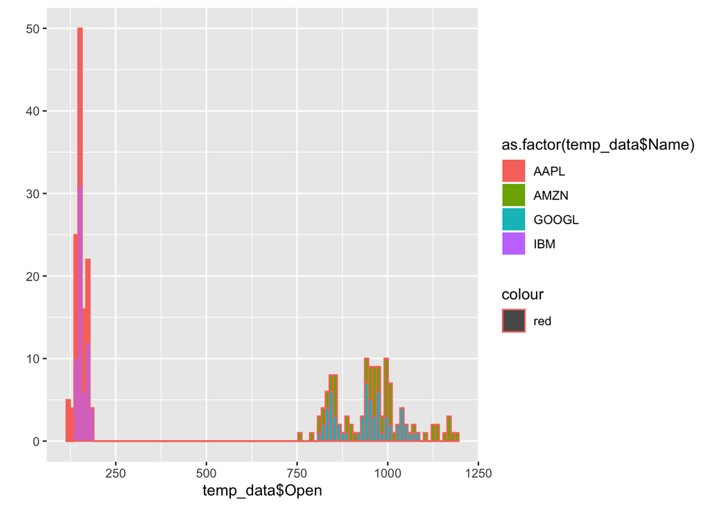

```r
library(ggplot2)
library(dplyr)
new_data <- data %>% group_by(Name)

temp_data <- new_data %>% filter(Name == c("AAPL", "IBM","AMZN", "GOOGL"))

qplot(temp_data$Open, fill=as.factor(temp_data$Name), bins=100, colour="red")
```

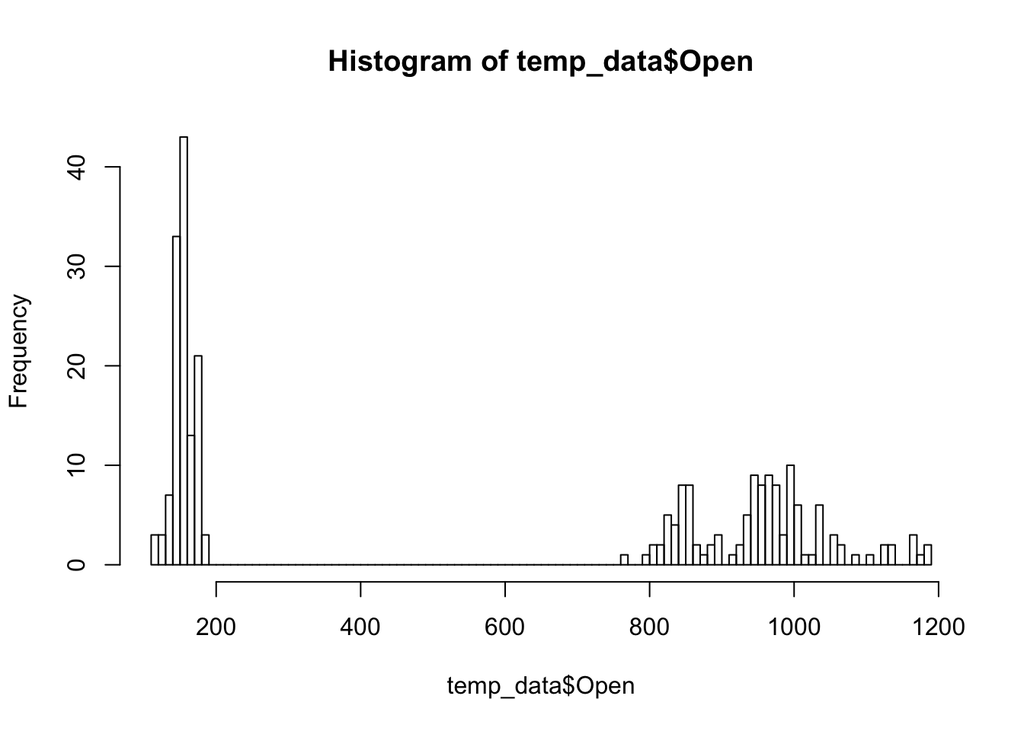

```r
hist(temp_data$Open, breaks=100)
```

## Histogramas con la librería base de R

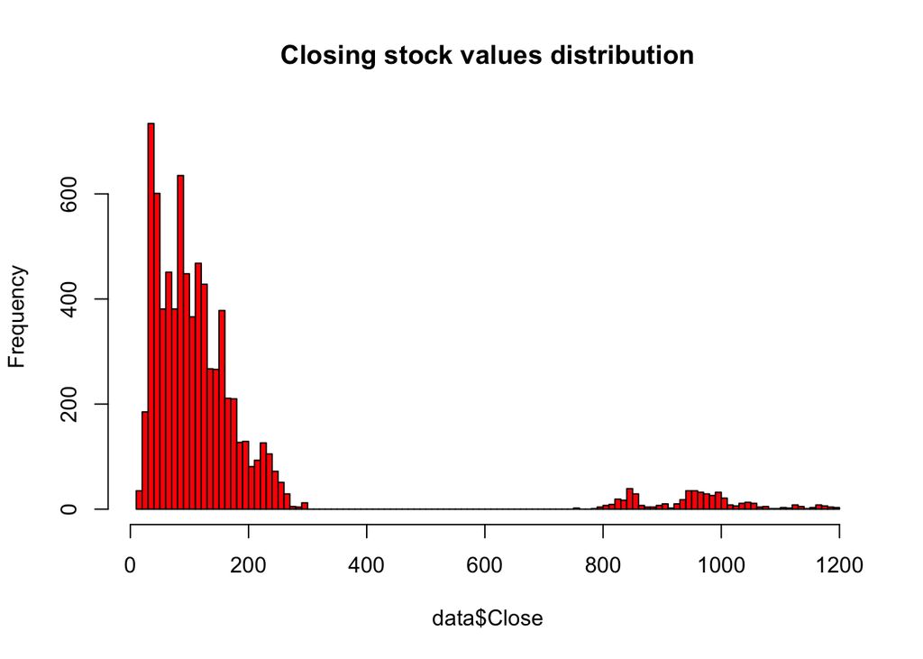

```r
## Histograma con la librería base de R
hist(data$Close, border = "black", col ="red", breaks=100,
     main = "Closing stock values distribution")
```

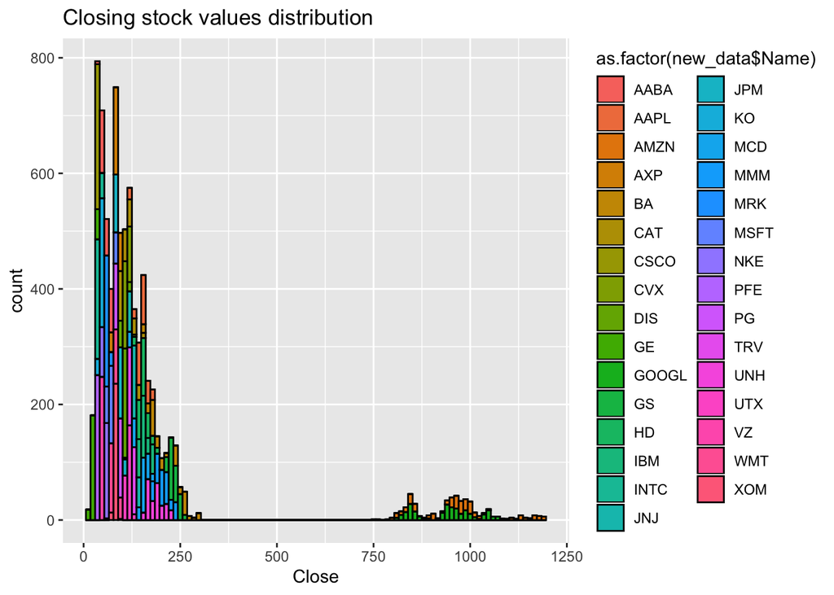

```r
## Histograma utilizando ggplot2

g <- ggplot(data, aes(x=Close, fill=as.factor(new_data$Name))) + geom_histogram(colour='black',bins=100) + ggtitle("Closing stock values distribution")

g
```

## Gráfico de caja

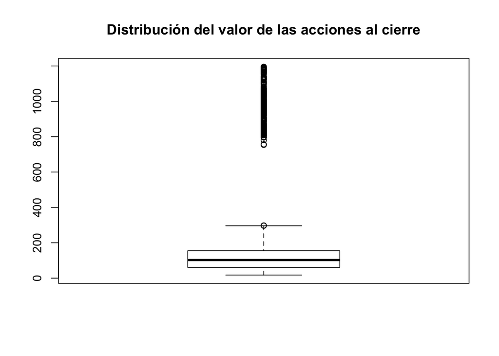

```r
## Gráfico de caja y bigotes con la librería base de R
boxplot(data$Close, main="Distribución del valor de las acciones al cierre")
```

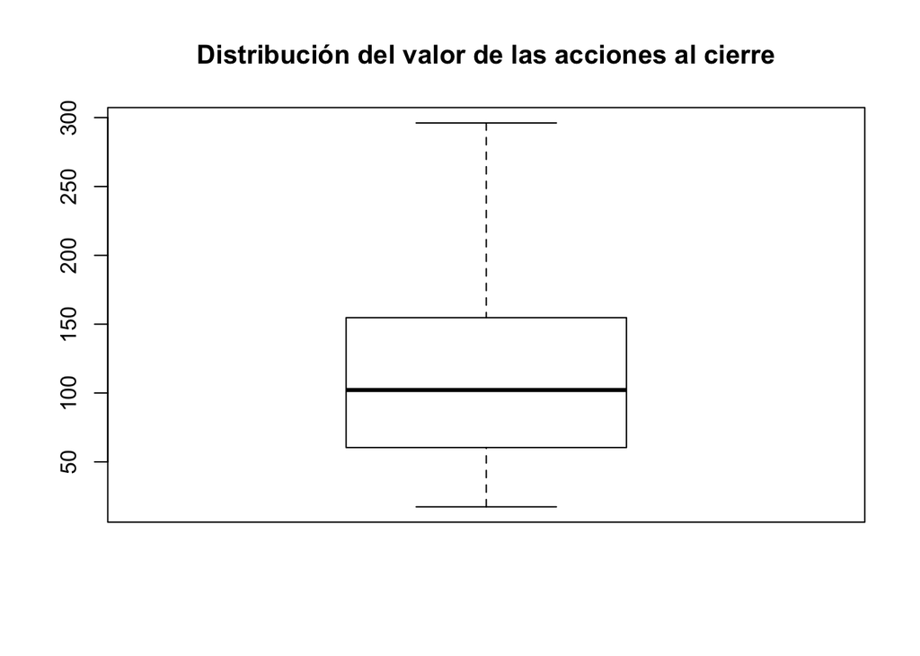

```r
boxplot(data$Close, main="Distribución del valor de las acciones al cierre", outline = FALSE)
```

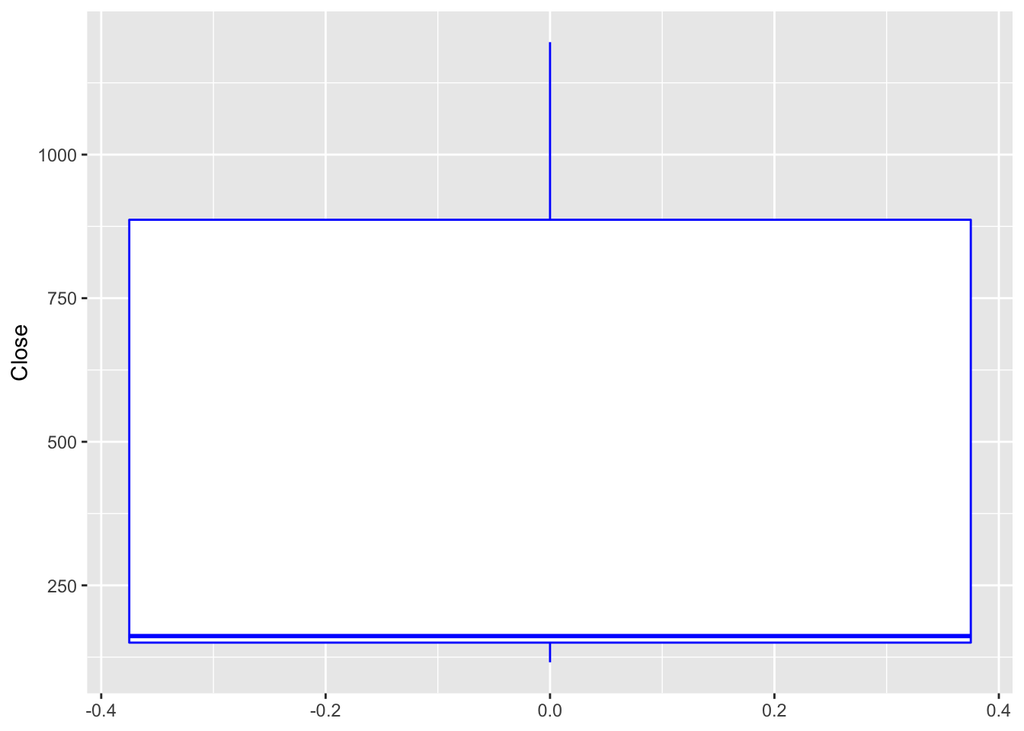

```r
data <- data[data$Name == "AMZN" | data$Name == "AAPL" | data$Name == "IBM",]

## Grafico de caja y bigotes con la librería ggplot2
g <- ggplot(data, aes(y=Close))+geom_boxplot(color="blue")
g
```

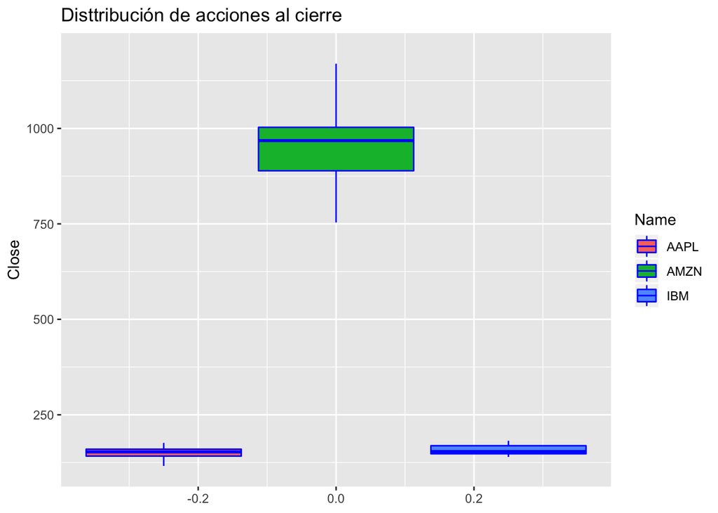

```r
g <- ggplot(data, aes(y=Close,fill=Name))+geom_boxplot(color="blue", outlier.shape = NA) + ggtitle("Disttribución de acciones al cierre")

g
```

## Graficar series de datos

```r
library(lubridate)
```

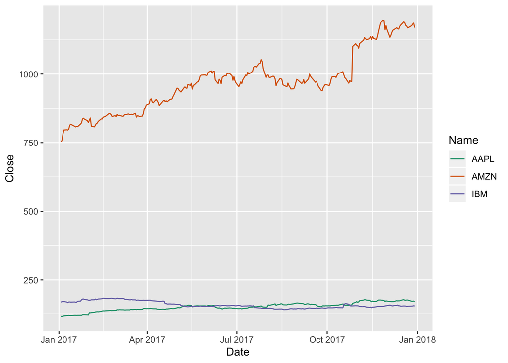

```r
data$Date <- ymd(data$Date)

g <- ggplot(data, aes(x=Date, y=Close, color=Name))
g <- g + geom_line() + scale_color_brewer(palette= "Dark2")

g
```

## Grafica de dispersión

Las gráficas de dispersión nos permiten visualizar el comportamiento entre dos variables. Generalmente queremos observar si una variable tiene efecto en otra variable. Por convención, la variable dependiente se gráfica en el eje vertical y la variable independiente se grafica en el eje horizontal.

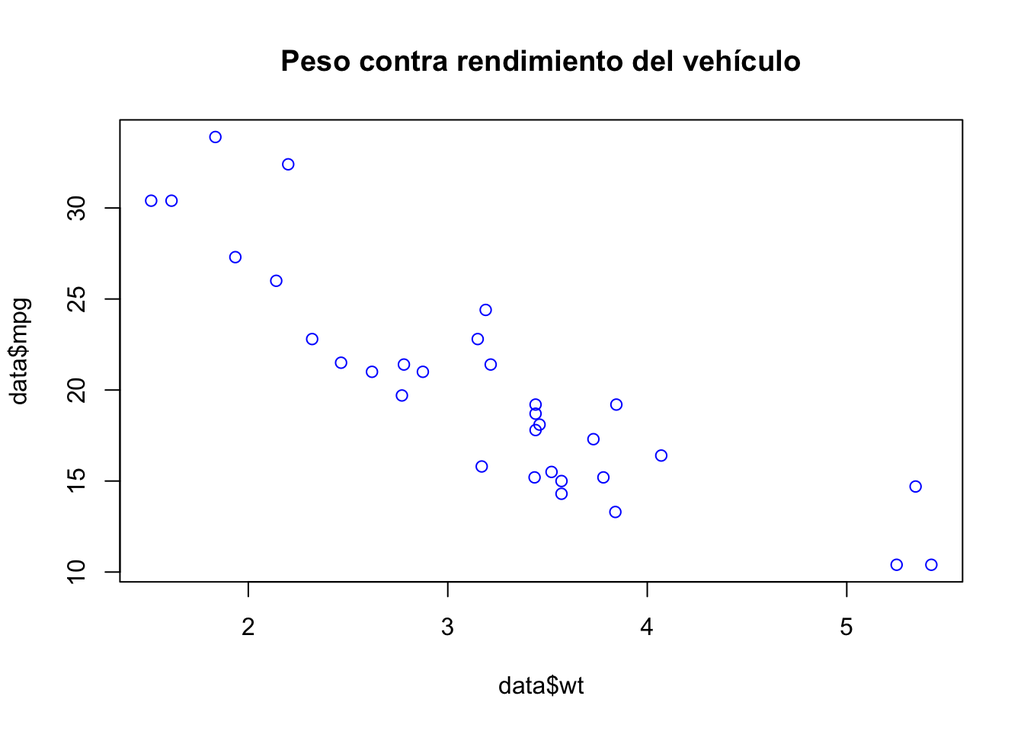

```r
data <- mtcars
## Gráfica de dispersión con la librería base de R

plot(data$wt, data$mpg,col="blue", main="Peso contra rendimiento del vehículo")
```

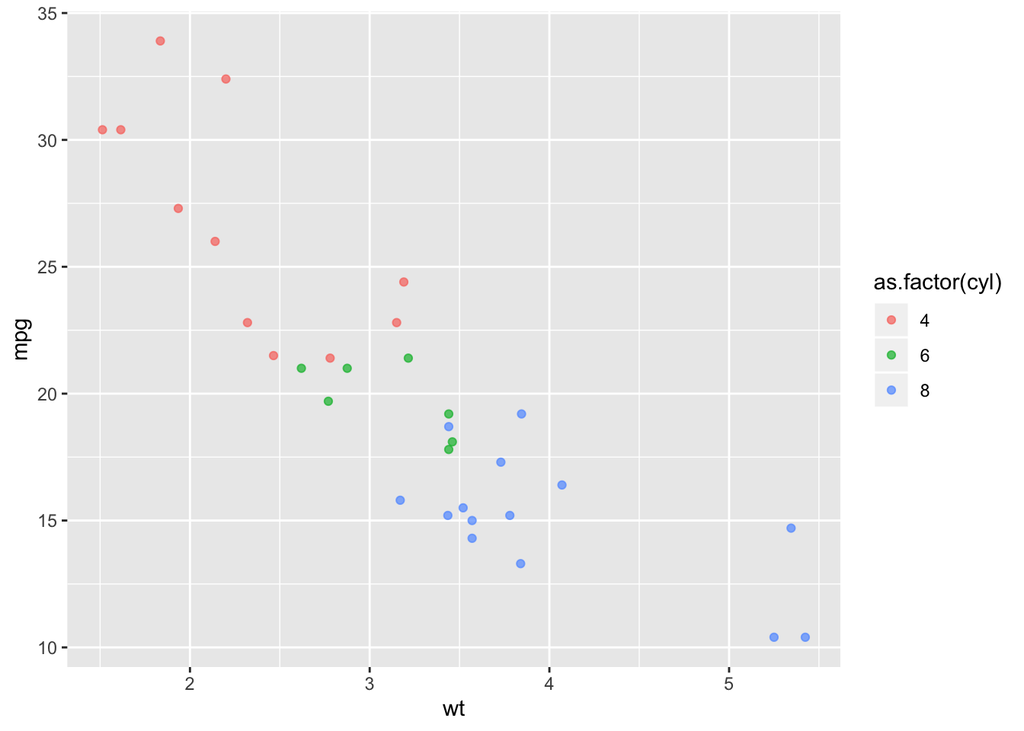

```r
## Crear gráfica de dispersión con la librería GGPLOT
g <- ggplot(data, aes(wt, mpg, color=as.factor(cyl))) + geom_point(alpha=0.7)

g
```

## Grafica de tipo violín

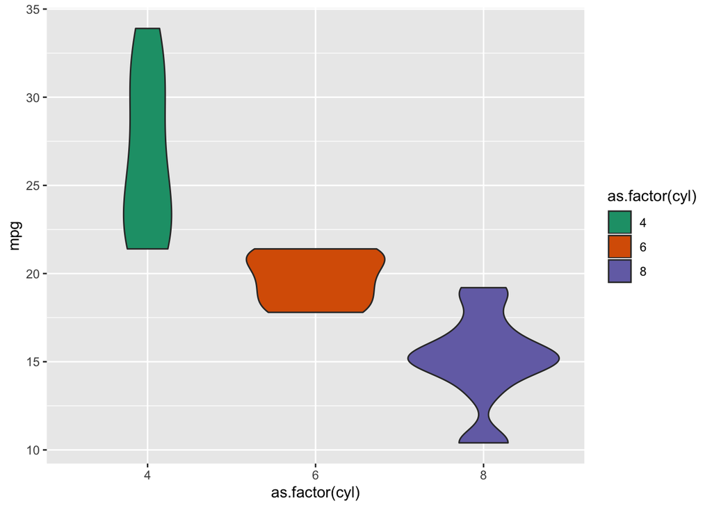

```r
## Este tipo de gráficas solo se pueden realizar con la librería ggplot2
g <- ggplot(data, aes(as.factor(cyl), mpg , fill=as.factor(cyl)))
g <- g + geom_violin()
g <- g + scale_fill_brewer(palette = "Dark2")

g
```